# MAE augmentation - Calculated variables at the participant and visit code level

Author

Mariam Rahali Masbouri, Khadija Rahali Masbouri, Laura Symul, Laura Vermeren

Published

July 2, 2026

```r
library(tidyverse)
library(magrittr)
library(gt)
library(patchwork)
library(grid)
library(gridExtra)
# library(factoextra)
# library(SummarizedExperiment)
# library(tidySummarizedExperiment)
# library(MultiAssayExperiment)

tmp <- fs::dir_map("R scripts/", source)
tmp <- fs::dir_map("../VIBRANT-99-utils/R/", source)
rm(tmp)
theme_set(theme_light())
```

```r
mae_files <-
  fs::dir_ls(
    get_03_output_dir(),
    regexp = "mae_full_03_.*\\.rds$"
  ) |>
  sort(decreasing = TRUE) |>
  magrittr::extract(1)

mae <- readRDS(mae_files)

rm(mae_files)
```

# Calculated variables at the participant and visit code level

# Calculated variables at the weekly visit code level

```r
mae@metadata$calc_vars_weekly_visit_code <-
  mae@colData |>
  as_tibble() |>
  select(uid, pid, visit_code, visit_type) |>
  filter(!is.na(pid), !is.na(visit_code), visit_type == "Clinic") |>
  distinct()
```

## Days since last dose

> based on the study product exposure data

We calculate the number of days since last dose of the study product based on the `exposure` table constructed in 01a. We first calculate the number of days since last dose at the participant and study day which is the corresponding study product exposure variable being > 0, and then we add this variable to the `calc_vars_weekly_visit_code` table by merging by `uid`.

Since the rationale behind this variable is to assess the number of days since last dose of the study product before the weekly clinic visit, we calculate this variable at the daily visit code level, and then we will merge it to the weekly visit code level table.

```r
tmp <- mae@metadata$calc_vars_study_day |>
  select(pid, study_day) |>
  distinct() |>
  arrange(pid, study_day)

exposure <-
  tibble(tmp) |>
  left_join(
    mae@metadata$exposures |>
      select(pid, study_day, daily_self_reported_exposure_sp),
    by = join_by(pid, study_day)
  ) |>
  left_join(
    mae@colData |>
      as_tibble() |>
      select(uid, pid, study_day, visit_code, visit_type, site),
    by = join_by(pid, study_day)
  )

exposure <-
  exposure |>
  arrange(pid, study_day) |>
  group_by(pid) |>
  mutate(
    last_sp_dose_day = case_when(
      daily_self_reported_exposure_sp > 0 ~ study_day,
      TRUE ~ NA_integer_
    ),
    last_sp_dose_day = zoo::na.locf(last_sp_dose_day, na.rm = FALSE),
    days_since_last_sp_dose = study_day - last_sp_dose_day
  ) |>
  ungroup() |>
  select(-last_sp_dose_day)
```

We add the variable `days_since_last_sp_dose` to the `calc_vars_weekly_visit_code` table.

```r
mae@metadata$calc_vars_weekly_visit_code <-
  mae@metadata$calc_vars_weekly_visit_code |>
  left_join(
    exposure |>
      select(uid, days_since_last_sp_dose),
    by = join_by(uid)
  )
```

## Days since last sex

We calculate the number of days since last sexual intercourse with and without condom, and with unknown condom use, based on the semen exposure variable calculated in the `calc_vars_study_day` table. We first calculate the number of days since last sexual intercourse with and without semen exposure and with unknown condom use, at the participant and study day which is the corresponding semen exposure variable being > 0, and then we add these variables to the `calc_vars_weekly_visit_code` table by merging by `uid`.

```r
tmp <- mae@metadata$calc_vars_weekly_visit_code$uid |> unique() |> sort()

sex <-
  mae@metadata$calc_vars_study_day |>
  select(
    pid,
    study_day,
    pv_sex_w_semen_exposure,
    pv_sex_wo_semen_exposure,
    other_sex_wo_semen_exp
  )
```

```r
sex <-
  sex |>
  arrange(pid, study_day) |>
  group_by(pid) |>
  mutate(
    # with condom only
    last_sex_day_w_semen_exp = case_when(
      pv_sex_w_semen_exposure > 0 ~ study_day,
      TRUE ~ NA_integer_
    ),
    last_sex_day_w_semen_exp = zoo::na.locf(
      last_sex_day_w_semen_exp,
      na.rm = FALSE
    ),
    days_since_last_sex_w_semen_exp = study_day - last_sex_day_w_semen_exp,

    # without condom only
    last_sex_day_wo_semen_exp = case_when(
      pv_sex_wo_semen_exposure > 0 ~ study_day,
      TRUE ~ NA_integer_
    ),
    last_sex_day_wo_semen_exp = zoo::na.locf(
      last_sex_day_wo_semen_exp,
      na.rm = FALSE
    ),
    days_since_last_sex_wo_semen_exp = study_day - last_sex_day_wo_semen_exp,
    # unknown condom use
    last_other_sex_day = case_when(
      other_sex_wo_semen_exp > 0 ~ study_day,
      TRUE ~ NA_integer_
    ),
    last_other_sex_day = zoo::na.locf(last_other_sex_day, na.rm = FALSE),
    days_since_last_other_sex = study_day - last_other_sex_day
  ) |>
  ungroup() |>
  select(
    -c(last_sex_day_wo_semen_exp, last_sex_day_w_semen_exp, last_other_sex_day)
  ) |>
  left_join(
    mae@colData |>
      as_tibble() |>
      select(uid, pid, study_day, visit_code, visit_type, site),
    by = join_by(pid, study_day)
  )
```

Add the variable `days_since_last_sex_wo_semen_exp`, `days_since_last_sex_w_semen_exp` and `days_since_last_other_sex` to the `calc_vars_weekly_visit_code` table.

```r
mae@metadata$calc_vars_weekly_visit_code <-
  mae@metadata$calc_vars_weekly_visit_code |>
  left_join(
    sex |>
      select(
        uid,
        days_since_last_sex_wo_semen_exp,
        days_since_last_sex_w_semen_exp,
        days_since_last_other_sex
      ),
    by = join_by(uid)
  )
```

## Any antibiotics since last visit

```r
antibiotics <-
  mae@metadata$calc_vars_study_day |>
  select(pid, study_day, starts_with("daily_exposure_cm_")) |>
  pivot_longer(
    cols = starts_with("daily_exposure_cm_"),
    names_to = "antibiotics",
    names_prefix = "daily_exposure_cm_",
    values_to = "exposure"
  ) |>
  left_join(
    mae@colData |>
      as_tibble() |>
      filter(visit_type == "Clinic") |>
      select(uid, pid, study_day, visit_code, site),
    by = join_by(pid, study_day)
  ) |>
  arrange(pid, antibiotics, study_day) |>
  group_by(pid, antibiotics) |>
  mutate(
    # we expand the weekly visit code backward to be able to report whether any antibiotics were taken since last dose
    exp_visit_code = visit_code |> zoo::na.locf(na.rm = FALSE, fromLast = TRUE),
    exp_visit_code = case_when(
      (exp_visit_code == visit_code) ~ lead(exp_visit_code),
      TRUE ~ exp_visit_code
    ),

    # we also count the number of days since last antibiotics dose for each antibiotic class
    last_antibiotics_day = case_when(
      exposure > 0 ~ study_day,
      TRUE ~ NA_integer_
    ),
    last_antibiotics_day = zoo::na.locf(last_antibiotics_day, na.rm = FALSE),
    days_since_last_antibiotics = study_day - last_antibiotics_day
  )
```

```r
antibiotics_at_clinic_visits <-
  left_join(
    antibiotics |>
      group_by(pid, antibiotics, exp_visit_code) |>
      summarize(
        since_last_visit = sum(exposure, na.rm = TRUE),
        .groups = "drop"
      ) |>
      dplyr::rename(visit_code = exp_visit_code),

    antibiotics |>
      filter(!is.na(visit_code)) |>
      select(
        pid,
        antibiotics,
        visit_code,
        study_day,
        days_since_last_abx = days_since_last_antibiotics
      ),

    by = join_by(pid, antibiotics, visit_code)
  ) |>
  mutate(
    days_since_last_abx = case_when(
      (days_since_last_abx == 0) & (since_last_visit == 0) ~ NA_integer_,
      TRUE ~ days_since_last_abx
    )
  ) |>
  filter(!is.na(visit_code)) |>
  select(pid, antibiotics, study_day, visit_code, everything())
```

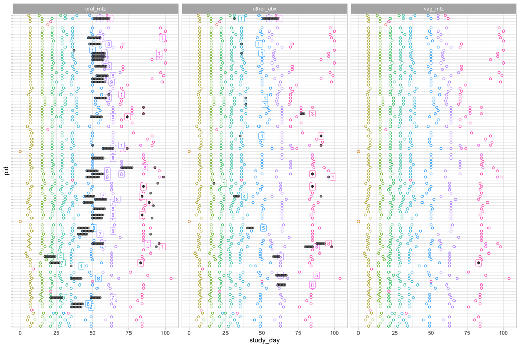

```r
antibiotics |>
  filter(exposure > 0) |>
  ggplot() +
  facet_grid(. ~ antibiotics) +
  aes(x = study_day, y = pid) +
  geom_point(
    data = antibiotics_at_clinic_visits |> filter(study_day < 125),
    aes(col = visit_code),
    shape = 1
  ) +
  geom_label(
    data = antibiotics_at_clinic_visits |> filter(since_last_visit > 0),
    aes(col = visit_code, label = since_last_visit),
    size = 3
  ) +
  geom_point(alpha = 0.5) +
  guides(col = "none") +
  theme(axis.text.y = element_blank())
```

We add this data to the `calc_vars_weekly_visit_code` table. We will have one variable for each antibiotic class indicating whether the participant took any antibiotics of that class since last clinic visit, and another variable indicating the number of days since last dose of antibiotics of that class.

```r
tmp <-
  mae@metadata$calc_vars_weekly_visit_code |>
  left_join(
    antibiotics_at_clinic_visits |>
      dplyr::rename(
        n_since_last_visit = since_last_visit,
        days_since_last = days_since_last_abx
      ) |>
      pivot_wider(
        names_from = antibiotics,
        values_from = c(n_since_last_visit, days_since_last),
        names_vary = "slowest"
      ) |>
      mutate(uid = str_c(pid, "_", visit_code)) |>
      relocate(uid, .before = everything()) |>
      select(-pid, -study_day, -visit_code),
    by = join_by(uid)
  )

mae@metadata$calc_vars_weekly_visit_code <- tmp
```

# Saving the `MultiAssayExperiment` objects

We save the MAE for downstream analyses.

```r
saveRDS(
  mae,
  str_c(
    get_03_output_dir(),
    "mae_full_04_",
    today() |> str_remove_all("-"),
    ".rds"
  )
)
```